# Exploratory factor analysis

Romanova

11 ноября 2018 г

Набор данных об американских университетах. В составе даных 44 признака, харакеризующих с разных сторон уровень обучающихся в университете, его пристижность, преподавателей и т.д. Также, как и в предыдущем случае (отчет по АГК), провели заранее агк для скоррелированных групп признаков и перешли к максимально информативным признакам.

```r
pca.quality<-dudi.pca(Un1[,c(1:10)],nf=1,scannf = FALSE)
new.Univ<-data.frame(-pca.quality$li) #качество студентов
colnames(new.Univ)<-c("quality")
new.Univ$applicants<--dudi.pca(Un1[,11:13],nf=1,scannf = FALSE)$li #приток студентов, количественная характеристика
new.Univ$super.students<--dudi.pca(Un1[,14:15],nf=1,scannf = FALSE)$li # процент отличников
new.Univ$num.students<-dudi.pca(Un1[,16:17],nf=1,scannf = FALSE)$li # количество студентов (количественная характеристика)
new.Univ$tuition<-dudi.pca(Un1[,18:19],nf=1,scannf = FALSE)$li # стоимость обучения
new.Univ$competence<-dudi.pca(Un1[,23:24],nf=1,scannf = FALSE)$li # компетентность преподавателей
new.Univ$fs.ratio<-Un1[,25] # отношение числа преподавателей к числу студентов (чем больше, тем лучше)
new.Univ$donate<-Un1[,26] # процент успешных выпускников
new.Univ$instruct<-Un1[,27] # средства, выделяемые на одного ученика
new.Univ$graduate<-Un1[,28] # процент выпустившихся судентов
new.Univ$salary<--dudi.pca(Un1[,29:36],nf=1,scannf = FALSE)$li # заработок преподавателей
new.Univ$num.teachers<--dudi.pca(Un1[,37:41],nf=1,scannf = FALSE)$li # количество преподавателей (количественная характеристика)
new.Univ<-as.matrix(new.Univ)
Univ1.active<-as.data.frame(new.Univ)
```

Сначала, чтобы не зайти слишком далеко, установим, есть ли в данных вообще какая-то структура, при помощи критерия Бартлетта. Этот критерий проверяет гипотезу о том, что $\Sigma=\mathbf{I}$.

```r
cor.Univ<-cor(Univ1.active)
cortest.bartlett(cor.Univ,n=115)
```

```
## $chisq
## [1] 733.7039
##
## $p.value
## [1] 2.2976e-113
##
## $df
## [1] 66
```

Гипотеза отвергается, следовательно, есть смысл продолжать. (На самом деле это говорит только о том, что некоторые наши переменные связаны друг с другом и всё).

Иногда для проверки наличия в данных каких-то скрытых признаков используют меру адекватности выборки Kaiser-Meyer-Olkin. Тест KMO проверяет, достаточно ли близки к нулю частные корреляции в ваших данных, чтобы предположить, что есть хотя бы один скрытый фактор, лежащий в основе ваших переменных. Минимально допустимое значение составляет 0,50, но большинство авторов рекомендуют значение 0,60 перед проведением факторного анализа.

```r
KMO(Univ1.active)
```

```
## Kaiser-Meyer-Olkin factor adequacy
## Call: KMO(r = Univ1.active)
## Overall MSA =  0.73
## MSA for each item =
##        quality     applicants super.students   num.students        tuition
##           0.76           0.77           0.67           0.52           0.71
##     competence       fs.ratio         donate       instruct       graduate
##           0.83           0.55           0.87           0.72           0.82
##         salary   num.teachers
##           0.82           0.68
```

Значение 0.73 – сойдет.

Теперь нужно подобрать модель, решить, сколько факторов мы будем извлекать. Для этого могут использоваться различные методы (здесь рассматриваем scree plot and parallel analysis)

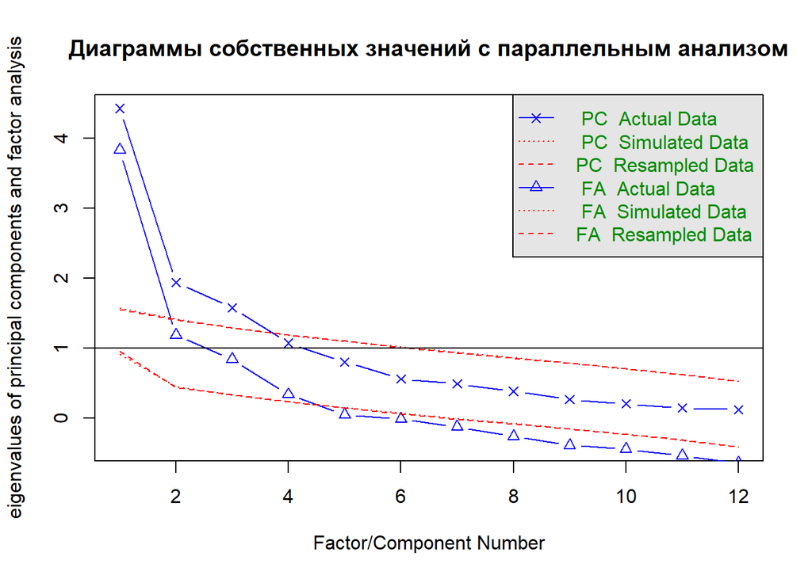

```
## Parallel analysis suggests that the number of factors =  4  and the number of components =  3
```

```r
fa.parallel(Univ1.active,n.iter = 100,main = "Диаграммы собственных значений с параллельным анализом",fa="both",fm="mle")
```

Нам советуют брать 4 фактора. Первые 4 собственных значений (треугольники) превышают среднее значение собственных значений, полученных на основании 100 смоделированных матриц данных (для белого шума). По критерию scree plot как таковому тоже +- видно, что “камни начинают сыпаться” после 4го фактора.

Проведем факторный анализ без вращений.

```r
efa.res<-fa( Univ1.active, nfactors=4, fm="mle",rotate = "none")
```

Пробуем интерпретировать полученные факоры.

```r
print(efa.res$loadings,cutoff=0.3, sort = TRUE)
```

```
##
## Loadings:
##                ML1    ML2    ML3    ML4
## competence      0.677
## fs.ratio        0.603 -0.440 -0.321
## instruct        0.923
## graduate        0.591         0.378  0.448
## salary          0.662
## applicants      0.461  0.709
## num.students           0.748 -0.450
## num.teachers    0.590  0.693
## quality         0.519         0.604
## super.students  0.478         0.696 -0.335
## tuition         0.373                0.518
## donate                        0.341
##
##                  ML1   ML2   ML3   ML4
## SS loadings    3.728 1.875 1.473 0.721
## Proportion Var 0.311 0.156 0.123 0.060
## Cumulative Var 0.311 0.467 0.590 0.650
```

Первый фактор влияет почти на все переменные. Мы бы хотели больше нулей. Вращаем. Сначала попробуем ортогонально.

```r
efa.res<-fa( Univ1.active, nfactors=4, fm="mle",rotate = "varimax",scores = "Bartlett")
print(efa.res$loadings,cutoff=0.3,sort = TRUE)
```

```
##
## Loadings:
##                ML3    ML2    ML1    ML4
## quality         0.757
## super.students  0.883
## applicants      0.317  0.688         0.448
## num.students           0.876
## num.teachers           0.836
## fs.ratio                      0.821
## instruct                      0.900
## tuition                              0.615
## graduate        0.508                0.653
## competence      0.347         0.477
## donate          0.387
## salary          0.330         0.384  0.381
##
##                  ML3   ML2   ML1   ML4
## SS loadings    2.274 2.108 2.006 1.409
## Proportion Var 0.190 0.176 0.167 0.117
## Cumulative Var 0.190 0.365 0.532 0.650
```

Вращаем косоугольно:

```r
efa.res<-fa( Univ1.active, nfactors=4, fm="mle",rotate = "oblimin")
print(efa.res$loadings,cutoff=0.3,digits = 2,sort = TRUE)
```

```
##
## Loadings:
##                ML1   ML2   ML3   ML4
## fs.ratio        0.87
## instruct        0.90
## applicants            0.60        0.48
## num.students          0.92
## num.teachers          0.80
## quality                     0.66
## super.students              0.93
## tuition                    -0.30  0.65
## graduate                          0.74
## competence      0.43
## donate                      0.32
## salary          0.33              0.35
##
##                 ML1  ML2  ML3  ML4
## SS loadings    1.93 1.93 1.71 1.54
## Proportion Var 0.16 0.16 0.14 0.13
## Cumulative Var 0.16 0.32 0.46 0.59
```

Марица стала значительно “чище”. Остановимся на косоугольных вращениях.

Итак, пусть будет

```r
efa.res<-fa( Univ1.active, nfactors=4, fm="mle",rotate = "oblimin")
efa.res
```

```
## Factor Analysis using method =  ml
## Call: fa(r = Univ1.active, nfactors = 4, rotate = "oblimin", fm = "mle")
## Standardized loadings (pattern matrix) based upon correlation matrix
##                  ML1   ML2   ML3   ML4   h2    u2 com
## quality         0.06 -0.08  0.66  0.24 0.64 0.364 1.3
## applicants     -0.14  0.60  0.12  0.48 0.78 0.222 2.1
## super.students  0.03  0.01  0.93 -0.10 0.83 0.174 1.0
## num.students   -0.01  0.92 -0.19 -0.16 0.82 0.180 1.1
## tuition         0.18 -0.02 -0.30  0.65 0.42 0.584 1.6
## competence      0.43  0.13  0.20  0.23 0.47 0.533 2.2
## fs.ratio        0.87 -0.06 -0.07 -0.15 0.68 0.319 1.1
## donate         -0.08 -0.02  0.32  0.19 0.17 0.829 1.8
## instruct        0.90  0.05  0.07  0.13 0.95 0.052 1.1
## graduate        0.06 -0.02  0.20  0.74 0.72 0.278 1.2
## salary          0.33  0.21  0.14  0.35 0.49 0.512 3.0
## num.teachers    0.12  0.80  0.21  0.10 0.84 0.156 1.2
##
##                        ML1  ML2  ML3  ML4
## SS loadings           2.06 2.03 1.87 1.83
## Proportion Var        0.17 0.17 0.16 0.15
## Cumulative Var        0.17 0.34 0.50 0.65
## Proportion Explained  0.26 0.26 0.24 0.23
## Cumulative Proportion 0.26 0.53 0.77 1.00
##
##  With factor correlations of
##      ML1  ML2  ML3  ML4
## ML1 1.00 0.09 0.25 0.29
## ML2 0.09 1.00 0.10 0.28
## ML3 0.25 0.10 1.00 0.40
## ML4 0.29 0.28 0.40 1.00
##
## Mean item complexity =  1.6
## Test of the hypothesis that 4 factors are sufficient.
##
## The degrees of freedom for the null model are  66  and the objective function was  6.72 with Chi Square of  733.7
## The degrees of freedom for the model are 24  and the objective function was  0.47
##
## The root mean square of the residuals (RMSR) is  0.03
## The df corrected root mean square of the residuals is  0.05
##
## The harmonic number of observations is  115 with the empirical chi square  14.75  with prob <  0.93
## The total number of observations was  115  with Likelihood Chi Square =  50.54  with prob <  0.0012
##
## Tucker Lewis Index of factoring reliability =  0.888
## RMSEA index =  0.105  and the 90 % confidence intervals are  0.06 0.136
## BIC =  -63.34
## Fit based upon off diagonal values = 0.99
## Measures of factor score adequacy
##                                                    ML1  ML2  ML3  ML4
## Correlation of (regression) scores with factors   0.97 0.96 0.94 0.91
## Multiple R square of scores with factors          0.95 0.91 0.88 0.83
## Minimum correlation of possible factor scores     0.89 0.83 0.76 0.66
```

Интерпретировать фактороры удобно при помощи следующей диаграммы (при базовых настройках функции здесь все совсем красивенько, но нам нужны эти пересекающиеся стрелочки):

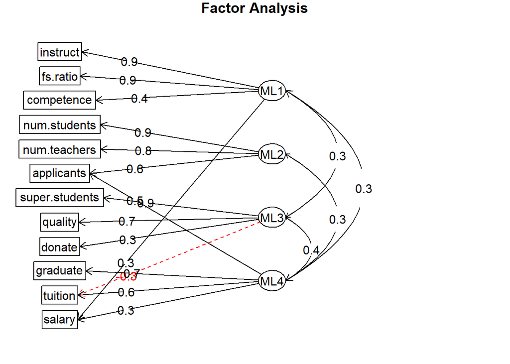

```r
fa.diagram(efa.res,cut = 0.25,simple = FALSE)
```

Второй фактор, влияющий на взаимосвязи исходных признаков, – размер университета. Первый факор – качество преподавательского состава. Третий фактор – качество самих студентов. Четвертый фактор – престижность университета.

Так как мы использовали косоугольные вращения, нужно посмотреть и на матрицу factor structure корреляций между исходными признаками и извлеченными факторами.

```r
print(efa.res$Structure, cutoff=0.3, digits=3)
```

```
##
## Loadings:
##                ML1    ML2    ML3    ML4
## quality                       0.764  0.498
## applicants             0.733  0.335  0.653
## super.students                0.905
## num.students           0.860
## tuition                              0.569
## competence      0.561         0.416  0.471
## fs.ratio        0.799
## donate                        0.375
## instruct        0.957         0.354  0.429
## graduate        0.314         0.503  0.827
## salary          0.488  0.354  0.388  0.560
## num.teachers           0.864  0.360  0.443
##
##                  ML1   ML2   ML3   ML4
## SS loadings    2.504 2.326 2.518 2.769
## Proportion Var 0.209 0.194 0.210 0.231
## Cumulative Var 0.209 0.403 0.612 0.843
```

Эти результаты, в принципе, не противоречат интерпретации факторов, приведенной выше. Но интерпретировать факторы только на основе factor structure сложно, так как много больших по модулю значений (в отличие от factor pattern, который мы максимально упростили при помощи вращений).

Биплот (для вычисления факторных значений используется метод Бартлетта):

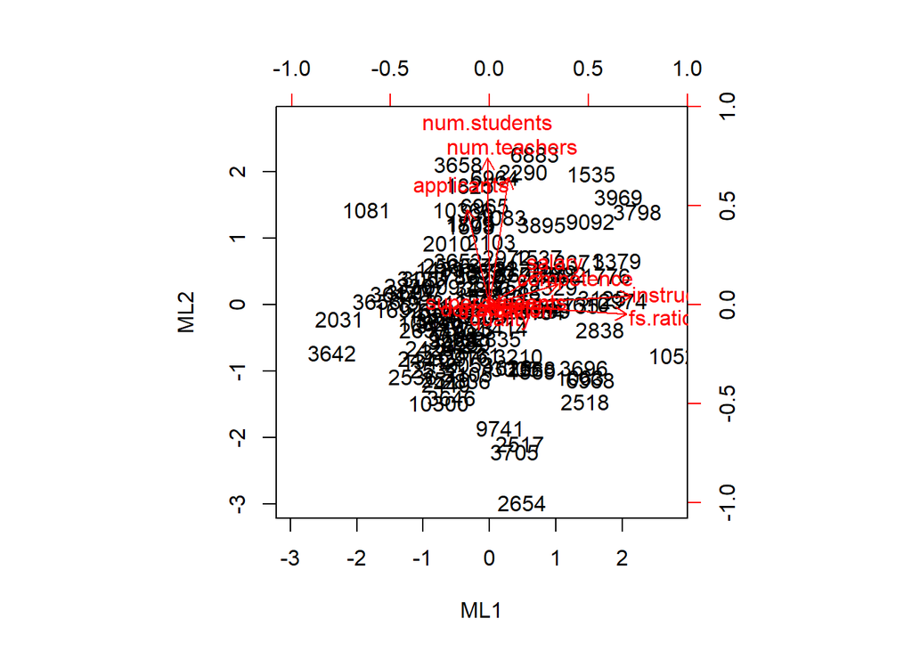

```r
biplot(efa.res$scores[], loadings(efa.res))
```

Общность (communality) для каждой переменной – это процент дисперсии, который объясняется извлекаемыми факторами. (Конечно, хорошо, если факторы объясняют как можно больше дисперсии в каждой переменной.)

```r
efa.res$communality
```

```
##        quality     applicants super.students   num.students        tuition
##      0.6359988      0.7780763      0.8264301      0.8195699      0.4161077
##     competence       fs.ratio         donate       instruct       graduate
##      0.4673241      0.6811060      0.1708317      0.9482572      0.7218396
##         salary   num.teachers
##      0.4875890      0.8443499
```

Факторный анализ не объясняет уникальности признаков:

```r
efa.res$uniquenesses
```

```
##        quality     applicants super.students   num.students        tuition
##     0.36400121     0.22192374     0.17356986     0.18043006     0.58389230
##     competence       fs.ratio         donate       instruct       graduate
##     0.53267592     0.31889401     0.82916831     0.05174277     0.27816036
##         salary   num.teachers
##     0.51241100     0.15565010
```

Процент успешных студентов (donate) обладает сильной уникальностью. Также не слишком хорошо объясняются переменные tuition, competence, salary.

### Остаточные корреляции

Воспроизведенные и остаточные корреляции. Дополнительным способом проверки числа выделенных факторов является вычисление корреляционной матрицы, которая близка исходной, если факторы выделены правильно. Эта матрица называется воспроизведенной корреляционной матрицей. Для того чтобы увидеть, как эта матрица отклоняется от исходной корреляционной матрицы (с которой начинался анализ), можно вычислить разность между ними. Полученная матрица называется матрицей остаточных корреляций. Остаточная матрица может указать на “несогласие”, т.е. на то, что рассматриваемые коэффициенты корреляции не могут быть получены с достаточной точностью на основе имеющихся факторов.

Матрица остаточных корреляций для нашей модели:

```r
residuals(efa.res)
```

```
##                qulty applc spr.s nm.st tuitn cmptn fs.rt donat instr gradt
## quality         0.36
## applicants     -0.05  0.22
## super.students  0.00  0.01  0.17
## num.students    0.02 -0.02 -0.01  0.18
## tuition         0.01  0.00  0.00 -0.01  0.58
## competence      0.12 -0.03 -0.05  0.02 -0.09  0.53
## fs.ratio       -0.01 -0.02  0.00 -0.03  0.06 -0.05  0.32
## donate         -0.01  0.02  0.01 -0.02  0.02  0.00  0.02  0.83
## instruct       -0.01  0.00  0.00  0.00 -0.01  0.01  0.00  0.00  0.05
## graduate        0.01 -0.01 -0.01 -0.01  0.00  0.00 -0.01 -0.01  0.00  0.28
## salary          0.07  0.04  0.01  0.04  0.05  0.04 -0.02 -0.07  0.00 -0.04
## num.teachers    0.00  0.01  0.00  0.00  0.01 -0.01  0.04  0.01  0.00  0.01
##              salry nm.tc
## salary        0.51
## num.teachers -0.06  0.16
```

```r
efa.res$fit
```

```
## [1] 0.924522
```

```r
efa.res$fit.off
```

```
## [1] 0.9922422
```

Есть критерии, которые изначально помогают выбрать количество факторов на основе того, насколько хорошо модель приближает корреляционную матрицу. Критерий VSS - Very Simple Structure Criterion. Статистика VSS:
$$VSS
=
\frac{\sum s_{ij}^{2}-\sum {s_{ij}^{\ast}}^{2}}{\sum s_{ij}^{2}},$$

где $\mathbb{S}=(s_{ij})$ — выборочная корреляционная матрица, $S^{\ast}=(s_{ij}^{\ast})=\mathbb{S}-\hat{\mathbb{F}_{r}^{\prime}}\hat{\mathbb{F}_{r}^{\prime}}^{\mathrm{T}}$ — матрица остатков. То есть 1-относительная ошибка. Таким образом, чем значение больше, тем лучше. Отметим, что в $\hat{\mathbb{F}_{r}^{\prime}}$ не есть $\hat{\mathbb{F}_{r}}$. Тут входят не все веса, а только $c$ наибольших (по модулю) для каждой переменной. (тут реализована тенденция людей смотреть только на несколько самых больших коэффициентов и интерпретировать только их). То есть тут используется упрощенная матрица факторных весов. с (complexity) изменяется от 1 до количества факторов.

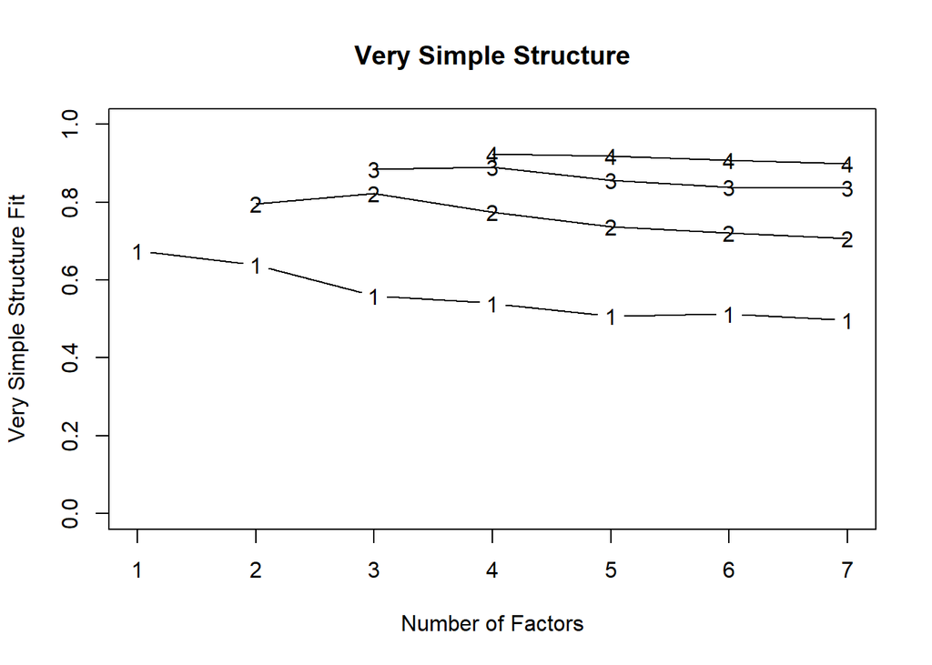

```
##
## Very Simple Structure
## Call: vss(x = x, n = n, rotate = rotate, diagonal = diagonal, fm = fm,
##     n.obs = n.obs, plot = plot, title = title, use = use, cor = cor)
## VSS complexity 1 achieves a maximimum of 0.68  with  1  factors
## VSS complexity 2 achieves a maximimum of 0.82  with  3  factors
##
## The Velicer MAP achieves a minimum of 0.07  with  4  factors
## BIC achieves a minimum of  -63.34  with  4  factors
## Sample Size adjusted BIC achieves a minimum of  -5.71  with  6  factors
##
## Statistics by number of factors
##   vss1 vss2   map dof chisq    prob sqresid  fit RMSEA BIC SABIC complex
## 1 0.68 0.00 0.071  54 408.9 5.5e-56     9.3 0.68 0.247 153 323.3     1.0
## 2 0.64 0.80 0.078  43 247.7 1.4e-30     5.8 0.80 0.211  44 179.6     1.2
## 3 0.56 0.82 0.067  33 107.6 7.9e-10     3.3 0.89 0.147 -49  55.3     1.6
## 4 0.54 0.77 0.067  24  50.5 1.2e-03     2.2 0.92 0.105 -63  12.5     1.7
## 5 0.51 0.74 0.098  16  28.9 2.4e-02     1.8 0.94 0.091 -47   3.6     1.9
## 6 0.51 0.72 0.119   9   8.6 4.8e-01     1.3 0.95 0.016 -34  -5.7     1.6
## 7 0.50 0.71 0.170   3   1.8 6.1e-01     1.4 0.95 0.000 -12  -2.9     1.9
##   eChisq   SRMR eCRMS eBIC
## 1 387.96 0.1599 0.177  132
## 2 188.76 0.1115 0.138  -15
## 3  53.84 0.0596 0.084 -103
## 4  14.75 0.0312 0.052  -99
## 5   7.55 0.0223 0.045  -68
## 6   1.68 0.0105 0.028  -41
## 7   0.65 0.0065 0.031  -14
```

```r
VSS(Univ1.active,n=7,rotate = "varimax",fm="mle" )
```

Модель с 4мя факторами лучше всех, ура! Значит, можем не удалять с позором все то, что сделали выше (впрочем, мы в начале использовали другие методы для определения числа факторов, они также имеют полное право на существование, возможно, даже большее, чем этот “критерий”).

### Метод-остаточные корреляции

Метод minres основан на минимизации остаточных корреляций в матричной норме Фробениуса (по недиагональным элементам). Взвешенный вариант минимизирует взвешенную сумму квадратов. Решение по методу максимального правдопобобия схоже с решением по wls.

Рассмотрим результаты факторного анализа с использованием 3х методов нахождения факторных весов (без вращений):

```r
wls <- fa(Univ1.active, nfactors=4,rotate="none",fm="wls")
minres <-  fa(Univ1.active, nfactors=4,rotate="none",fm="minres")
mle <- fa(Univ1.active, nfactors=4,rotate="none",fm="mle")
```

Значение fit.off, хранящееся в объекте типа fa(), показывает, насколько хорошо матрица в модели приближает исходную корреляционную матрицу.
$$\mathrm{fit.off}=
1-
\frac{\sum_{i\neq j}r_{ij}^{2}}{\sum_{i\neq j}s_{ij}^{2}},$$

где $R=(r_{ij})$ – матрица остаточных корреляций, а $S=(s_{ij})$ – выборочная корреляционная матрица.

Очевидно, что норма Фробениуса (по недиагональным элементам) будет минимальна в методе minres (по построению метода), то есть значение переменной fit.off наоборот будет максимально:

```r
minres$fit.off
```

```
## [1] 0.9936553
```

```r
wls$fit.off
```

```
## [1] 0.9934621
```

```r
mle$fit.off
```

```
## [1] 0.9922422
```

Также понятно, что если измерять ошибку в другой норме, результат может быть другим.